# TALLER_7nov_Amaya

Juan Pablo Mosquera Marin - 20221020026 Ana Laura Morcote Chacon - 20221020010 Hana Sofia Pinilla Manrique - 20221020092 Juan David Amaya Patiño - 20221020057

2026-11-08

# Taller Hotelling: ¿son distintos estos grupos?

## 1. El encargo

**Cliente y comparaciones.** Nuestro cliente es un banco de Taiwán (es un supuesto de la clase: los datos son reales, 30.000 titulares de tarjeta de crédito, y el encargo lo imaginamos) que quiere perfilar a sus clientes según cuánto pagan de su tarjeta cada mes, para decidir a quiénes estudiar con más detalle y qué hacer con el crédito otorgado. Le sirven dos comparaciones. La primera, **de una muestra**: ¿los universitarios (`EDUCATION = 2`: 14.030 clientes, 46,8 % de la base, casi la mitad) pagan distinto del cliente promedio? La referencia es el promedio de toda la base de 30.000 clientes; no es una meta del banco ni una cifra publicada, y así se dice en el informe. La segunda, **de dos muestras**: ¿los hombres (11.888) y las mujeres (18.112) pagan distinto?, para saber si el sexo sirve como atajo para decidir a quién estudiar.

**Variables.** Usamos las seis `PAY_AMT1` a `PAY_AMT6`: el monto que cada cliente pagó en cada uno de los seis meses (de abril a septiembre de 2005). Las escogimos porque son el comportamiento de pago realmente observado (no una calificación), están todas en la misma unidad y se mueven juntas (correlación promedio entre meses de 0,44), así que no basta compararlas una por una: como con los módulos de la prueba Saber, estar por encima en abril y en mayo es en buena parte el mismo hallazgo contado dos veces. Los montos son muy asimétricos (asimetría entre 11 y 30; hay pagos de hasta NT$ 1.684.259), y unos pocos pagos enormes moverían todo el cálculo; por eso trabajamos con $\log(1+\text{monto})$. En esa escala una diferencia se lee, aproximadamente, como un porcentaje (0,10 es cerca de 10 % más). Al final de cada comparación se revisa qué pasa con los montos sin transformar.

## 2. Una muestra: ¿los universitarios son distintos de la referencia?

### 2.1 Variable por variable

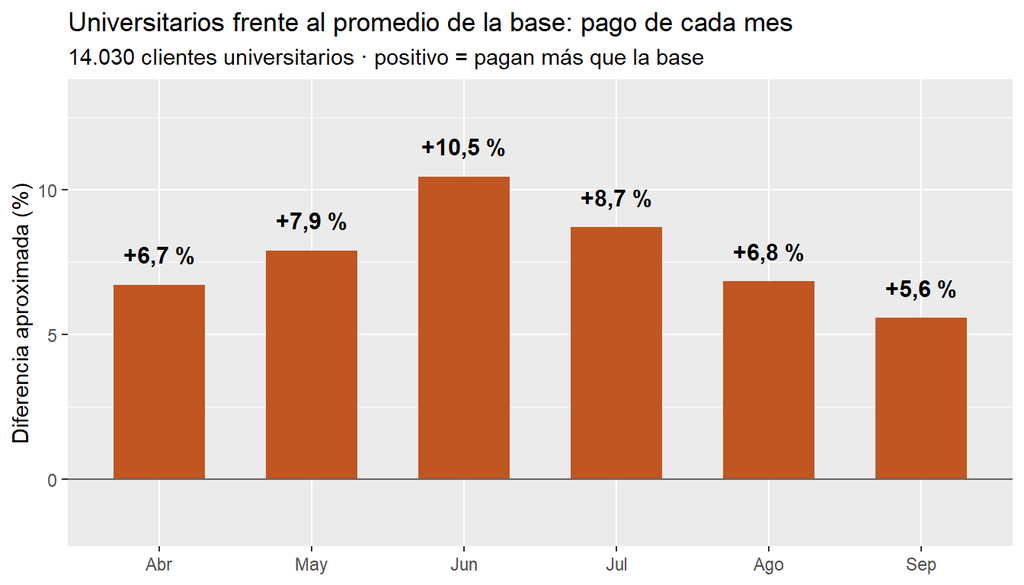

Los universitarios pagan más que el promedio de la base en los seis meses, entre 5,6 % y 10,5 % más, con la mayor brecha en Jun. Todas las barras suben juntas, así que es una diferencia de nivel (no de perfil), y como los meses se mueven juntos no son seis hallazgos sino casi uno.

No presentar seis barras sueltas: pedir una sola medida de cuánto se aleja el grupo con los seis meses al tiempo.

### 2.2 ¿Es grande? La distancia $D$

El promedio de los universitarios está a 0,035 desviaciones del promedio de la base, contando los seis meses al tiempo. Una distancia de 1 es una desviación completa y esta ni siquiera llega a una décima: el universitario típico se parece muchísimo más al cliente promedio de lo que se diferencia. No se puede decir que los universitarios «pagan distinto» a secas, sino que la brecha es muy pequeña.

### 2.3 ¿Es real? `hotelling_1()` y la simulación

```
##         n         D        T2         F         p
## 1.403e+04 3.477e-02 1.696e+01 2.826e+00 9.472e-03
```

```
## distancia_tipica_por_azar          la_mayor_de_1000      la_de_universitarios
##                     0.014                     0.028                     0.035
```

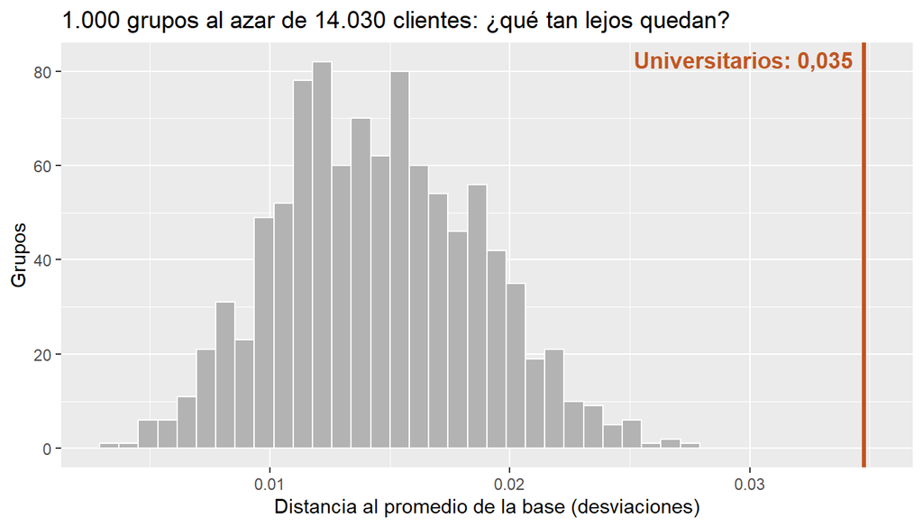

Un grupo de 14.030 clientes sacado al azar queda típicamente a 0,014 desviaciones y el más lejano de los 1.000 quedó a 0,028; los universitarios están a 0,035, y el cálculo exacto con `hotelling_1()` da una probabilidad de azar de una en 106.

Ningún grupo al azar se les acercó, así que la diferencia es real y no es mala suerte (la simulación es la referencia más exacta aquí: los universitarios son casi la mitad de la base, y la fórmula, que trata la referencia como un valor fijo, deja más margen al azar del que realmente hay); pero real no es lo mismo que grande, y esta diferencia es real y muy pequeña.

El banco puede afirmar que los universitarios pagan algo distinto, siempre acompañado de la cifra de cuánto: 0,035 desviaciones.

Revisión con los montos sin transformar:

```
##         n         D        T2         F         p
## 1.403e+04 7.569e-02 8.038e+01 1.339e+01 3.359e-15
```

```
## PAY_AMT1 PAY_AMT2 PAY_AMT3 PAY_AMT4 PAY_AMT5 PAY_AMT6
##     -583     -814     -669     -451     -347     -499
```

Con los montos en NT$ sin transformar, $D$ es 0,076 y el promedio de los universitarios queda NT$ 347 a 814 por debajo del de la base, al revés de lo que mostraba la escala logarítmica.

El promedio en NT$ lo arrastran unos pocos pagos enormes (por eso el cliente típico paga un poco más, pero el promedio de dinero es menor), y aun así la distancia sigue por debajo de una décima de desviación, así que la conclusión de fondo (diferencia real y muy pequeña) no depende de la escala.

El banco puede decir que ninguna de las dos lecturas le da base para tratar a los universitarios como un grupo aparte.

### 2.4 ¿Separa?

```
##                   mediana_base universitarios_bajo_la_mediana
##                           6.93                        6960.00
##                    de_cada_100
##                          49.60
```

```
## PAY_AMT1 PAY_AMT2 PAY_AMT3 PAY_AMT4 PAY_AMT5 PAY_AMT6
##     1170        0        0     9494     3000      378
```

Los 6.960 universitarios, 49,6 de cada 100, quedan por debajo de la mediana de la base, cuando si fueran iguales a la base serían 50; uno de ellos (cliente de la fila 15682) pagó NT$ 14.042 en los seis meses y paga menos que 75 de cada 100 clientes de la base.

El grupo está apenas corrido hacia arriba y casi la mitad de sus integrantes está del lado de los que pagan menos: diferencia no es separación, y ser universitario casi no dice nada sobre cuánto paga un cliente.

Se concluye que «universitario» no sirve como criterio para seleccionar a quién estudiar: un filtro por educación pondría en el mismo saco a clientes que pagan mucho y a clientes que pagan poco.